# Problem: Predicting Airplane Delays

The goals of this notebook are:

- Process and create a dataset from downloaded .zip files
- Perform exploratory data analysis (EDA)
- Establish a baseline model
- Move from a simple model to an ensemble model
- Perform hyperparameter optimization
- Check feature importance

## Introduction to business scenario

You work for a travel booking website that wants to improve the customer experience for flights that were delayed. The company wants to create a feature to let customers know if the flight will be delayed because of weather when they book a flight to or from the busiest airports for domestic travel in the US.

You are tasked with solving part of this problem by using machine learning (ML) to identify whether the flight will be delayed because of weather. You have been given access to the a dataset about the on-time performance of domestic flights that were operated by large air carriers. You can use this data to train an ML model to predict if the flight is going to be delayed for the busiest airports.

## About this dataset

This dataset contains scheduled and actual departure and arrival times reported by certified US air carriers that account for at least 1 percent of domestic scheduled passenger revenues. The data was collected by the U.S. Office of Airline Information, Bureau of Transportation Statistics (BTS). The dataset contains date, time, origin, destination, airline, distance, and delay status of flights for flights between 2013 and 2018.

### Features

For more information about features in the dataset, see [On-time delay dataset features](https://www.transtats.bts.gov/Fields.asp).

### Dataset attributions

Website: https://www.transtats.bts.gov/

Dataset(s) used in this lab were compiled by the U.S. Office of Airline Information, Bureau of Transportation Statistics (BTS), Airline On-Time Performance Data, available at https://www.transtats.bts.gov/DatabaseInfo.asp?DB_ID=120&DB_URL=Mode_ID=1&Mode_Desc=Aviation&Subject_ID2=0.

# Step 1: Problem formulation and data collection

### 1. Determine if and why ML is an appropriate solution to deploy for this scenario.

This is a decision making problem (deciding if a flight will be delayed or not) that will be otherwise difficult to solve through the traditional if-else programming paradigm or other concepts due to the large set of data to be processed in each iteration of decision making. However, ML approach is suitable for a binary decision making as is the case in this problem.

### 2. Formulate the business problem, success metrics, and desired ML output.

#### The problem

Customers at our travel booking agency would like to know if their flights would be delayed when they book flights through some busy airports and airlines from their location. It is hoped that this service would help improve our clients' experiences and satisfaction when they are able to make appropriate hotel and transport bookings in and out of their departure or destination location. Such service is provided by our competitors and we are losing customers.

#### Desired metrics

A 60% improvement in customer experience within the first 3 months of this service deployment is desired.

#### Desired output

The service should be able to advice customer if their flight would be delayed.

### 3. Identify the type of ML problem that you're working with.

The type of dataset available containing the features and a target outcome means this is a **supervised machine learning** problem specifically a **binary classification** problem

### 4. Analyze the appropriateness of the data that you're working with.

It is a large public dataset with several features and a target column which is appropriate for the problem. Though, the performance of the model trained on it will determine if it dataset is sufficient.

# Step 2: Data preprocessing and visualization

## 2.1 Data Preprocessing

1. The data was brought into a notebook environment from a public Amazon Simple Storage Service (Amazon S3) bucket for analysis.
2. Exploration of the files contained in the folder indicates the following - There is a total of 60 files (in '.csv' file format) in the dataset. - An HTML file contained in the folder briefly describes the features present in each file. - Each csv file contained dated records of about 585749 rows and 110 columns including a target column.
3. Columns of interest were selected and each file was filtered for those columns and merged into a single csv file named "data".

## 2.1 Data Preprocessing Cont'd.

4. Exploration of the combined files shows: * A total number 1,658,130 rows and 20 feature columns. - A 12 month record for the period of 2014 to 2017. - The data contain records for the top airlines and the origin and destination airports. - Null values in the data represent about 1.3% of the total records. They were hence dropped from the record before exploration.

## 2.1 Data Preprocessing Cont'd

5. The columns constist of float, int and pandas object data types. The object data type is a string datatype or categorical variables.
6. For the purpose of model training, the DephourofDay column was converted to categorical data type because it has no quantitative relationship with the target column.
7. Also the one-hot encoding was used to encode the categorical column in the dataset for the purpose of future model training.

## 2.2 Data Visualization

#### is_delay column

The is_delay column is not balance. Close to 80% of the records indicates that the flights were not delayed.

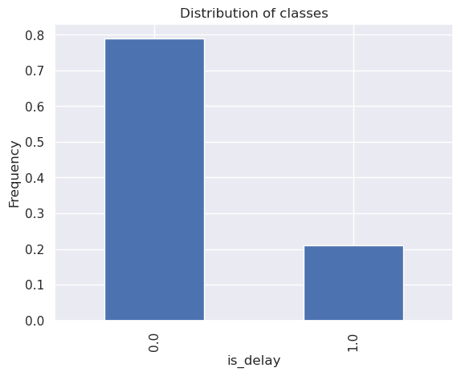

```python
(data.groupby('is_delay').size()/len(data) ).plot(kind='bar')
plt.ylabel('Frequency')
plt.title('Distribution of classes')
plt.show()
```

## 2.2 Data Visualization Cont'd

#### Other numerical columns

- The plots indicate the following: - June or the sixth month has comparatively the most delays. - The 20th hour of the day has the most delays in all hours of the rest of the day - The 1st, 4th and 5th days of the week have the most delays. Though the 4th appears higher by a small margin. - The "WN" airline has comparatively the most delays. - "ORD" and "SFO" have the most delays for the origin and destination airports respectively. - The flight distances have no impact on the chances of delay.

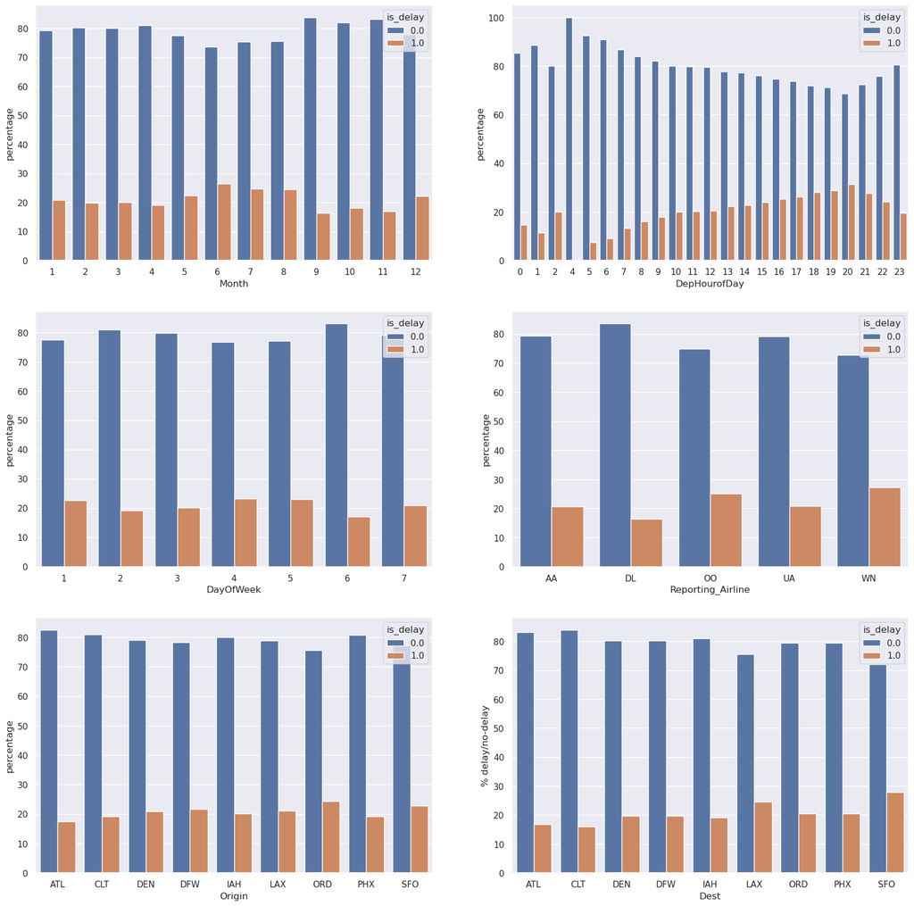

```python
viz_columns = ['Month', 'DepHourofDay', 'DayOfWeek', 'Reporting_Airline', 'Origin', 'Dest']
fig, axes = plt.subplots(3, 2, figsize=(20,20), squeeze=False)
# fig.autofmt_xdate(rotation=90)

for idx, column in enumerate(viz_columns):
    ax = axes[idx//2, idx%2]
    temp = data.groupby(column)['is_delay'].value_counts(normalize=True).rename('percentage').\
    mul(100).reset_index().sort_values(column)
    sns.barplot(x=column, y="percentage", hue="is_delay", data=temp, ax=ax)
    plt.ylabel('% delay/no-delay')


plt.show()
```

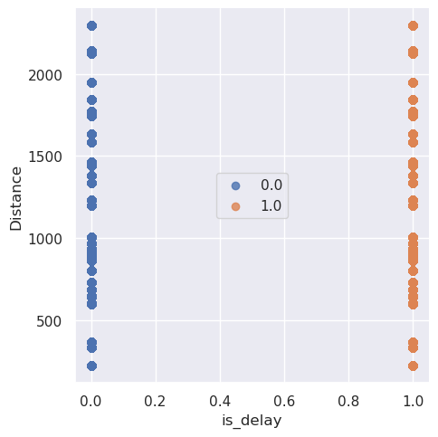

```python
sns.lmplot( x="is_delay", y="Distance", data=data, fit_reg=False, hue='is_delay', legend=False)
plt.legend(loc='center')
plt.xlabel('is_delay')
plt.ylabel('Distance')
plt.show()
```

# Step 3: Model training and evaluation

## 3.1 Pre-Model Training

The following preliminary step were used to prepare the dataset for model training:

1. Splitting of the data into `train_data`, `validation_data`, and `test_data` by using `sklearn.model_selection.train_test_split` function in Pandas
2. Conversion the dataset to an appropriate file format that the Amazon SageMaker training job can use i.e protobuf format using the record_set method of Amazon SageMaker.
3. Uploading the data to an S3 bucket.

## 3.2 Baseline Model Training

An Amazon SageMaker LinearLearner model was trained on the dataset using the following argument/parameters settings.

instance_count=1, instance_type='ml.m4.xlarge' predictor_type='binary_classifier' binary_classifier_model_selection_criteria='cross_entropy_loss')

## 3.3 Baseline Model Evaluation

The following can be deduced from the statistics and confusion matrix plot of the model.

- The confusion matrix indicates that the model's performance at predicting positive class (flight delayed) is poor relative to the negative class (flight not delayed).
- Even more so, the output statistics indicates a low sensitivity which is the percentage of positive identification.
- The marked differences in the model's accuracy, precision and recall could be attributed to the imbalance in the target column in the training set.
- From our business point of view sensitivity will be key to the success of our service considering our goal of helping clients determine if their flight might be delayed.
- Clearly the metric of interest is not good enough to address the objective of building a model to solve this particular problem.
- Adding more features to the training data is a common strategy in a case like this. Alternatively, one might consider other sampling techniques to address the imbalance that could have lead to low sensitivity and high specificity.

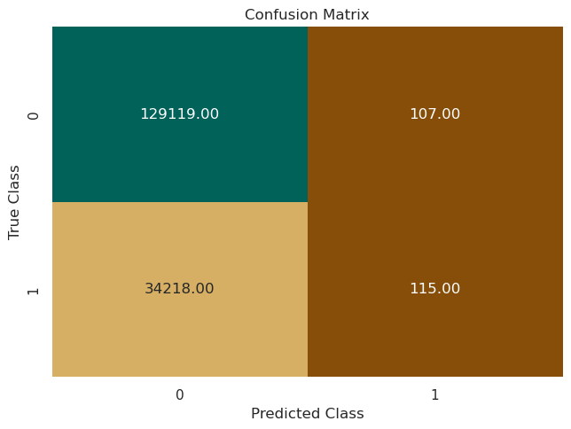

```python
plot_confusion_matrix(test_labels, target_predicted)
```

```
Sensitivity or TPR:  0.33495470829813884 %
Specificity or TNR:  99.91719932521319 %
Precision:  51.80180180180181 %
Negative Predictive Value:  79.05067437261613 %
False Positive Rate:  0.08280067478680761 %
False Negative Rate:  99.66504529170186 %
False Discovery Rate:  48.1981981981982 %
Accuracy:  79.01368924975085 %
Validation AUC 0.5012607701675567
```

[output not shown]

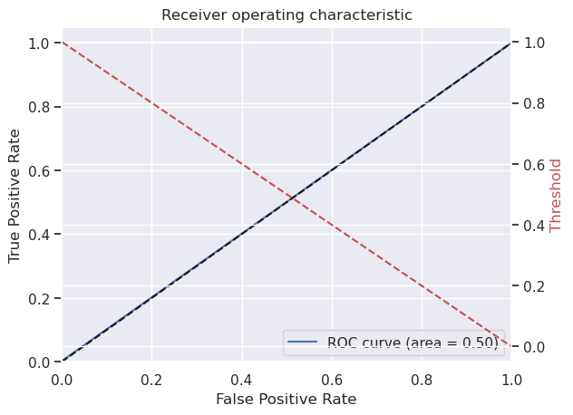

```python
plot_roc(test_labels, target_predicted)
```

# Step 4: Feature engineering

## 4.1 Consideration For Feature Engineering

1. The poor performance of the Baseline Model necessitate the need for argumenting the dataset with new ones that could impact on the next training and hyperparameters tunings iterations.
2. In this case, weather data for the period covered in the dataset and the origin and destination airports location were added to the previous dataset.
3. In addition, holiday record were included in the dataset which could further help the trained model performance on test data.
4. Weather data was fetched from https://shorturl.at/HIMPV  
   This dataset has information on wind speed, precipitation, snow, and temperature for cities by their airport codes.
5. Imputation for missing data was done using mean values in the respective features.

## 4.2 New Baseline Model Training and Evaluation.

1. Another Amazon SageMaker LinearLearner was trained using the feature engineered dataset and evaluated
2. The following conclusions can be reached: - The new model performed only relatively better than the previous model. - The improvement is unsatisfactory and cannot achieve the goals of the business. - It's sensitivity is still low and can hardly be used in production. - The AUC also suggest that the model is no better than mere guessing.

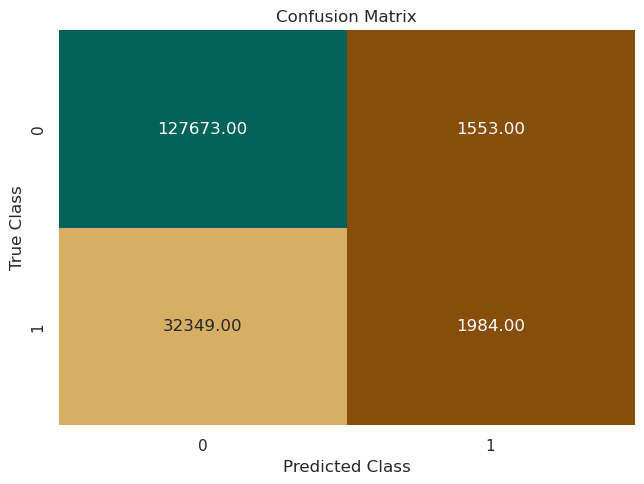

```python
plot_confusion_matrix(test_labels, target_predicted)
```

```
Sensitivity or TPR:  5.778696880552238 %
Specificity or TNR:  98.79822945846811 %
Precision:  56.09273395532938 %
Negative Predictive Value:  79.78465460999112 %
False Positive Rate:  1.20177054153189 %
False Negative Rate:  94.22130311944777 %
False Discovery Rate:  43.90726604467062 %
Accuracy:  79.27231152061336 %
Validation AUC 0.5228846316951017
```

[output not shown]

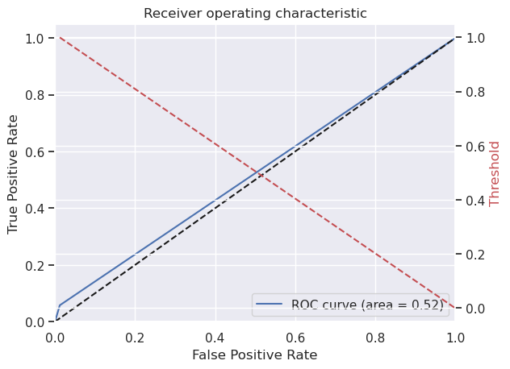

```python
plot_roc(test_labels, target_predicted)
```

## 4.3 Using XGBoost Classiffier

1. The poor performance of the previous model on argumented data necessitate training a different algorithm on the data. In this case XGBoost.
2. Again evaluation of the trained model indicates a slightly improved sensitivity and AUC. - This however still unsatisfactory.

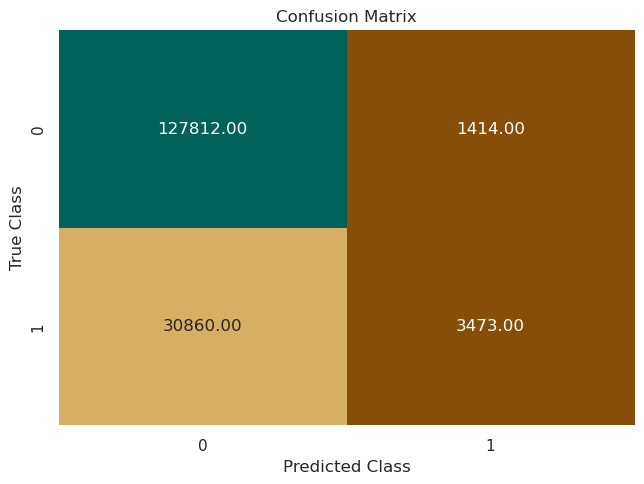

```python
plot_confusion_matrix(test_labels, target_predicted)
```

```
Sensitivity or TPR:  10.115632190603792 %
Specificity or TNR:  98.90579295188275 %
Precision:  71.06609371802742 %
Negative Predictive Value:  80.5510739134819 %
False Positive Rate:  1.0942070481172521 %
False Negative Rate:  89.88436780939621 %
False Discovery Rate:  28.933906281972583 %
Accuracy:  80.26767099334185 %
Validation AUC 0.5451071257124327
```

[output not shown]

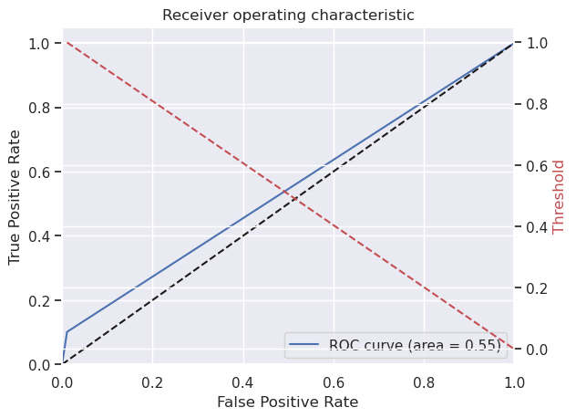

```python
plot_roc(test_labels, target_predicted)
```

## 4.4 Tuning Thresholds

1. Tuning the threshold value had remarkable impacts on the metrics of the model's performance
2. Compared to the previous models, the test set was relatively handled better. Moreover, adjusting the threshold value for the decision had a drastic effect on the test performance of the model. Largely, some lower threshold value increased both the desired sensitivity and maximise the AUC.

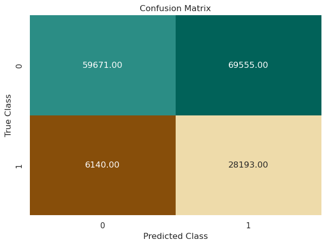

```python
# at 0.15 threshold
#print(target_predicted.head())

target_predicted['target'] = target_predicted['target'].apply(binary_convert)

test_labels = test.iloc[:,0]

#print(target_predicted.head())
plot_confusion_matrix(test_labels, target_predicted)
```

```
Sensitivity or TPR:  82.11633122651676 %
Specificity or TNR:  46.175692198164455 %
Precision:  28.842533862585423 %
Negative Predictive Value:  90.67025269331874 %
False Positive Rate:  53.824307801835545 %
False Negative Rate:  17.883668773483237 %
False Discovery Rate:  71.15746613741457 %
Accuracy:  53.72006431929762 %
Validation AUC 0.6414601171234061
```

[output not shown]

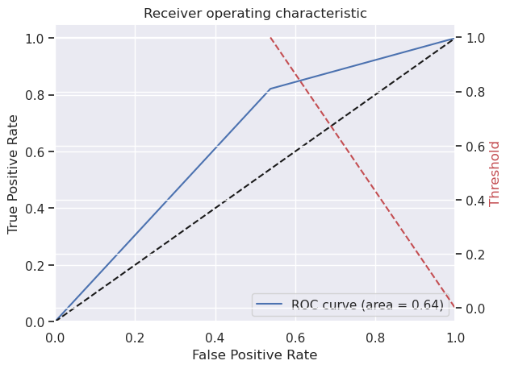

```python
plot_roc(test_labels, target_predicted)
```

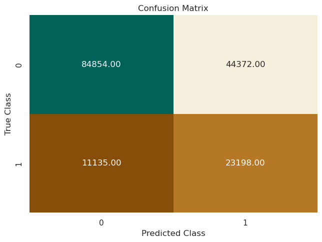

```python
# at 0.2 threshold
#print(target_predicted.head())

target_predicted['target'] = target_predicted['target'].apply(binary_convert)

test_labels = test.iloc[:,0]

#print(target_predicted.head())
plot_confusion_matrix(test_labels, target_predicted)
```

```
Sensitivity or TPR:  67.56764628782804 %
Specificity or TNR:  65.6632566201848 %
Precision:  34.331804055054015 %
Negative Predictive Value:  88.39971246705352 %
False Positive Rate:  34.33674337981521 %
False Negative Rate:  32.43235371217196 %
False Discovery Rate:  65.66819594494598 %
Accuracy:  66.06301090126499 %
Validation AUC 0.6661545145400641
```

[output not shown]

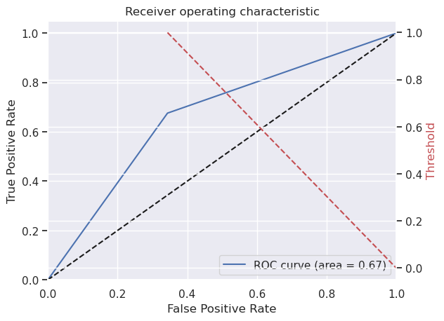

```python
plot_roc(test_labels, target_predicted)
```

## 4.5 Iterations of Hyperparameter Tunings

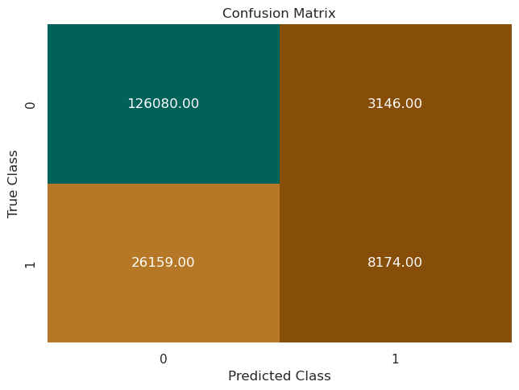

```python
plot_confusion_matrix(test_labels, target_predicted)
```

```
Sensitivity or TPR:  23.80799813590423 %
Specificity or TNR:  97.56550539365143 %
Precision:  72.20848056537102 %
Negative Predictive Value:  82.817149350692 %
False Positive Rate:  2.4344946063485677 %
False Negative Rate:  76.19200186409577 %
False Discovery Rate:  27.791519434628974 %
Accuracy:  82.08291809071956 %
Validation AUC 0.6068675176477784
```

[output not shown]

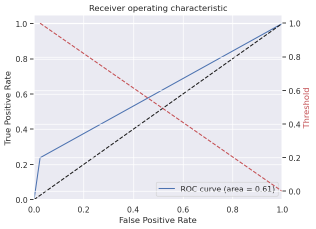

```python
plot_roc(test_labels, target_predicted)
```

### Some other thresholds

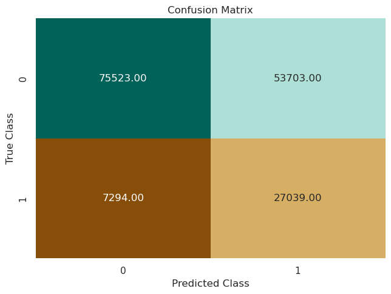

```
Sensitivity or TPR:  78.75513354498588 %
Specificity or TNR:  58.4425734759259 %
Precision:  33.488147432562975 %
Negative Predictive Value:  91.1926295325839 %
False Positive Rate:  41.5574265240741 %
False Negative Rate:  21.244866455014126 %
False Discovery Rate:  66.51185256743702 %
Accuracy:  62.706423981560164 %
Validation AUC 0.6859885351045589
```

[output not shown]

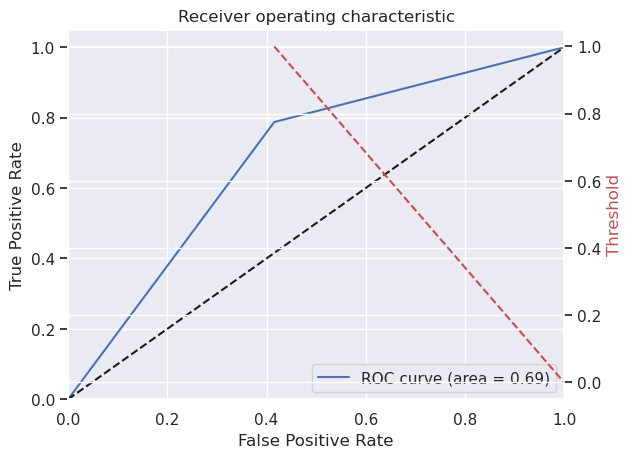

```python
plot_confusion_matrix(test_labels,  target_predicted)
plot_roc(test_labels, target_predicted)
```

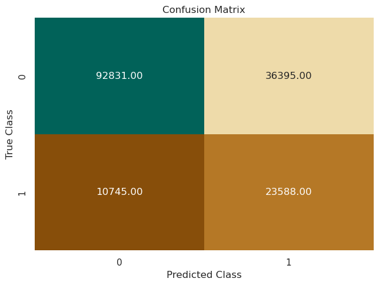

```
Sensitivity or TPR:  68.70357964640434 %
Specificity or TNR:  71.83616300125362 %
Precision:  39.3244752679926 %
Negative Predictive Value:  89.6259751293736 %
False Positive Rate:  28.163836998746383 %
False Negative Rate:  31.296420353595668 %
False Discovery Rate:  60.6755247320074 %
Accuracy:  71.17859610293533 %
Validation AUC 0.7026987132382898
```

[output not shown]

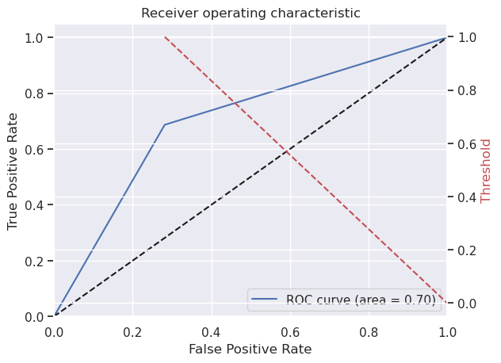

```python
plot_confusion_matrix(test_labels,  target_predicted)
plot_roc(test_labels, target_predicted)
```

# Conclusions

The following conclusions are made based on this project

- In some ways, through several iterations of trainings and hyperparameters tunings, the models got better and approached metrics that could meet the business goal. If I were to forge further I think I will do more tuning using wider range of values anddifferent hyperparameters.
- Generally, adding more dataset with several features improved the models' performance on test sets and metrics of the model. One technique that I used consistently in this project was to explore some lower and higher values of thresholds and evaluate its impact on key metrics of interest like AUC, Sensitivity and Specificity. These thresholds, particularly at lower values tend to give improved and comparatively better metrics and performance

# Conclusions Cont'd

- I think one of the biggest challenge is not being able to train and tune the model much longer and finding the right balance between the metric.
- Some key takeaway from this project are that - machine learning is an highly iterative process with lots of spaces to explore what works and what doesn't. - Patience is key to success - It is not an exhaustive process.-- -Iterations should be limited and one's objectives should be to find the right right metrics and balance that satisfy business needs in the least number of Iterations possible.